# Ted Cruz and Term Limits

Freddy Drennan

January 4, 2019

Senator Ted Cruz has proposed an [amendment](https://www.cruz.senate.gov/files/documents/Bills/20190103_termlimits.pdf) to the Constitution which would limit the term for a House Representative to 3 terms (6 years) and a senator to 2 terms (12 years). The amendment states that this would go into effect after 7 years of it’s acceptance.

I was curious what this might look like if it was enacted today. The first step is to find a website with the data, scrape it, and then clean it up. We’ll use `rvest` to scrape the data.

```r
library(rvest)
library(lubridate)
library(tidyverse)
library(stringr)
```

We’re going to scrape from [this](https://ballotpedia.org/List_of_current_members_of_the_U.S._Congress) site.

```r
url <- "https://ballotpedia.org/List_of_current_members_of_the_U.S._Congress"
site <- read_html(url) %>%
  html_table(fill = TRUE)
```

We see that the relevant data is in the first two tables.

```r
senate <- site %>%
  .[[1]]

house <- site %>%
  .[[2]]

DT::datatable(senate)
```

|  | Officeholder name | Office title | Date assumed office | Party affiliation |
| --- | --- | --- | --- | --- |
| 1 | Mark Warner | U.S. Senate Virginia | 2009-01-03 | Democratic Party |
| 2 | Tim Kaine | U.S. Senate Virginia | 2013-01-03 | Democratic Party |
| 3 | Chris Van Hollen | U.S. Senate Maryland | 2017-01-03 | Democratic Party |
| 4 | Ben Cardin | U.S. Senate Maryland | 2007-01-03 | Democratic Party |
| 5 | Dianne Feinstein | U.S. Senate California | 1993 | Democratic Party |
| 6 | Kamala D. Harris | U.S. Senate California | 2017-01-03 | Democratic Party |
| 7 | Tina Smith | U.S. Senate Minnesota | 2018-01-03 | Democratic Party |
| 8 | Amy Klobuchar | U.S. Senate Minnesota | 2007-01-03 | Democratic Party |
| 9 | Ted Cruz | U.S. Senate Texas | 2013-01-03 | Republican Party |
| 10 | John Cornyn | U.S. Senate Texas | 2002-12-02 | Republican Party |

[output cut: 90 more lines]

```r
DT::datatable(house)
```

|  | Officeholder name | Office title | Date assumed office | Party affiliation |
| --- | --- | --- | --- | --- |
| 1 | Jennifer Wexton | U.S. House Virginia District 10 | 2019-01-03 | Democratic Party |
| 2 | Andy Biggs | U.S. House Arizona District 5 | 2017-01-03 | Republican Party |
| 3 | Trey Hollingsworth | U.S. House Indiana District 9 | 2017-01-03 | Republican Party |
| 4 | Peter G. "Pete" Olson | U.S. House Texas District 22 | 2009-01-03 | Republican Party |
| 5 | Tom Rice | U.S. House South Carolina District 7 | 2013-01-03 | Republican Party |
| 6 | Aston Donald McEachin | U.S. House Virginia District 4 | 2017-01-03 | Democratic Party |
| 7 | Jesus Garcia | U.S. House Illinois District 4 | 2019-01-03 | Democratic Party |
| 8 | Nydia Velazquez | U.S. House New York District 7 | 2013-01-03 | Democratic Party |
| 9 | Tony Cardenas | U.S. House California District 29 | 2013-01-03 | Democratic Party |
| 10 | William "Will" Hurd | U.S. House Texas District 23 | 2015-01-03 | Republican Party |

[output cut: 428 more lines]

There are a few issues with the data. First, the dates are strings and we need to convert them to an actual date format in R for plotting. I also prefer my column names to be lower case and without spaces.

The function below creates a binary indicator stating whether the person is Republican or not. I’m only curious about Democrats and Republicans, so I filter out Independents. Finally, I create a column `years_in_office` which is self explanatory.

```r
clean_table <- function(table) {
  table %>%
    mutate(
      year_assumed = case_when(
        str_detect(`Date assumed office`, "\\-") ~ ymd(`Date assumed office`),
        TRUE ~ ymd(paste0(`Date assumed office`, "-01-01")))
    ) %>%
    transmute(name = `Officeholder name`,
              party = `Party affiliation`,
              year_assumed,
              republican = if_else(party == "Republican Party", 1, 0),
              years_in_office = year(Sys.time()) - year(year_assumed)) %>%
    arrange(year_assumed)
}
```

We clean the data and the add a key stating which branch of government the data belongs to.

```r
house_clean = clean_table(house) %>% mutate(key = "house")
senate_clean = clean_table(senate) %>% mutate(key = "senate")
```

Next, we select Democrats and Republicans and create a column called `too_long` which indicates wether the individual in question would technically be out of office at this point if the legislation was enforced today.

```r
washington = bind_rows(house_clean, senate_clean) %>%
  filter(party %in% c("Democratic Party", "Republican Party")) %>%
  mutate(too_long = case_when(
    key == "senate" ~ 12 < years_in_office,
    key == "house"  ~ 6 < years_in_office
  ))

DT::datatable(washington)
```

|  | name | party | year_assumed | republican | years_in_office | key | too_long |
| --- | --- | --- | --- | --- | --- | --- | --- |
| 1 | Don Young | Republican Party | 1973-03-06 | 1 | 46 | house | True |
| 2 | Hal Rogers | Republican Party | 1981-01-03 | 1 | 38 | house | True |
| 3 | Chris Smith | Republican Party | 1981-01-03 | 1 | 38 | house | True |
| 4 | Steny Hoyer | Democratic Party | 1981-05-19 | 0 | 38 | house | True |
| 5 | Marcy Kaptur | Democratic Party | 1983-01-01 | 0 | 36 | house | True |
| 6 | Peter Visclosky | Democratic Party | 1985-01-03 | 0 | 34 | house | True |
| 7 | Nancy Pelosi | Democratic Party | 1987-01-01 | 0 | 32 | house | True |
| 8 | Peter DeFazio | Democratic Party | 1987-01-01 | 0 | 32 | house | True |
| 9 | Fred Upton | Republican Party | 1987-01-03 | 1 | 32 | house | True |
| 10 | John Lewis | Democratic Party | 1987-01-03 | 0 | 32 | house | True |

[output cut: 524 more lines]

Next we can plot year year the person came into office and wether he or she is a Republican. In looking at the plot we see generally that Democrats tend to have more members what have been around for a while in the House and vice-verse in the Senate.

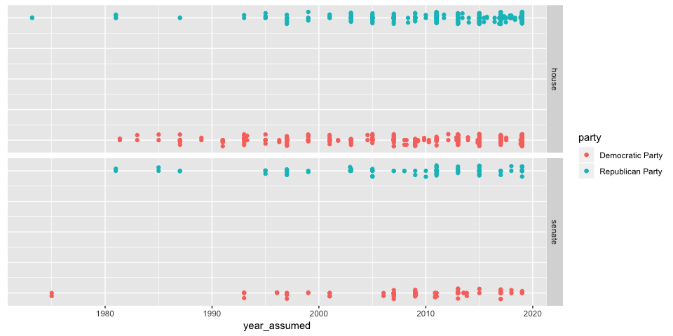

```r
washington %>%
  ggplot() +
  aes(x = year_assumed, y = republican, colour = party) +
  geom_point() +
  facet_grid(key ~.) +
  theme(axis.title.y = element_blank(),
        axis.ticks.y = element_blank(),
        axis.text.y = element_blank()) +
  geom_jitter(width = .1, height = .05)
```

Now let’s look at the numbers. If we were to enact the legislation today, how many members from each party will need to go? Overall, it’s about even between parties.

```r
washington %>%
  filter(too_long) %>%
  group_by(party) %>%
  summarise(n = n())
```

```
## # A tibble: 2 x 2
##   party                n
##   <chr>            <int>
## 1 Democratic Party   100
## 2 Republican Party    97
```

What about by party, by branch? A few more Democrats in the House vs. a few more in the Senate. Overall, I don’t get the impression that there is a huge political motivation behind the legislation.

```r
washington %>%
  filter(too_long) %>%
  group_by(party, key) %>%
  summarise(n = n())
```

```
## # A tibble: 4 x 3
## # Groups:   party [?]
##   party            key        n
##   <chr>            <chr>  <int>
## 1 Democratic Party house     89
## 2 Democratic Party senate    11
## 3 Republican Party house     81
## 4 Republican Party senate    16
```

What percentage of each branch, in each party would be required to leave?

```r
washington %>%
  group_by(key, party) %>%
  summarise(percent = sum(too_long, na.rm = TRUE)/length(too_long))
```

```
## # A tibble: 4 x 3
## # Groups:   key [?]
##   key    party            percent
##   <chr>  <chr>              <dbl>
## 1 house  Democratic Party   0.380
## 2 house  Republican Party   0.401
## 3 senate Democratic Party   0.244
## 4 senate Republican Party   0.302
```